# **APRENDIZAJE AUTOMATICO Y CIENCIA DE DATOS**

ENTREGA 2: ESTADÍSTICA DESCRIPTIVA MULTIVARIADA

Cesar Augusto Prieto Sarmiento

Universidad Nacional de Colombia  
Departamento de Estadística

ceprieto@unal.edu.co

# **ANÁLISIS EXPLORATORIO DE DATOS MULTIVARIADO**

En el análisis de datos provenientes de pacientes hospitalizados por diabetes, es fundamental entender los factores asociados con las readmisiones hospitalarias y cómo estos influyen en los perfiles de los pacientes. La alta tasa de readmisiones representa un desafío significativo para los sistemas de salud, ya que está relacionada con costos elevados y posibles deficiencias en la atención médica o la gestión del tratamiento.

Este proyecto busca aplicar técnicas multivariadas para explorar y analizar la información de manera integral. Las herramientas seleccionadas permiten identificar patrones ocultos en los datos y agrupar a los pacientes en segmentos homogéneos basados en características compartidas. Los objetivos específicos incluyen:

- **Reducir la dimensionalidad** de los datos y sintetizar la información clave mediante el Análisis de Componentes Principales (ACP).
- **Explorar las relaciones entre variables categóricas** utilizando el Análisis de Correspondencias Múltiples (ACM).
- **Segmentar los pacientes** en grupos homogéneos mediante métodos de agrupamiento, como K-means y Agrupamiento Jerárquico.
- **Generar insights** prácticos que puedan ser utilizados para mejorar la atención médica y reducir las tasas de readmisión hospitalaria.

La combinación de estas técnicas proporciona una perspectiva robusta para analizar los datos tanto desde un enfoque exploratorio como aplicado, permitiendo así responder preguntas clave sobre los perfiles de los pacientes y su relación con las variables relevantes.

Este análisis tiene un enfoque centrado en los datos y está diseñado para proporcionar bases sólidas para investigaciones futuras, tales como la implementación de modelos predictivos o la toma de decisiones clínicas basadas en datos.

# **ANÁLISIS DE COMPONENTES PRINCIPALES (ACP)**

## **ACP GENERAL PARA VARIABLES NUMERICAS**

El Análisis de Componentes Principales (ACP) es una técnica de reducción de dimensionalidad que permite sintetizar la información contenida en un conjunto de variables en un número menor de componentes no correlacionados. En este caso, se aplicará el ACP a las variables numéricas del conjunto de datos para identificar patrones y estructuras subyacentes.

```
## Rows: 101,763
## Columns: 8
## $ time_in_hospital   <dbl> 4, 2, 4, 5, 1, 7, 6, 3, 2, 3, 2, 4, 3, 3, 1, 4, 5, …
## $ num_lab_procedures <dbl> 66, 48, 21, 38, 6, 42, 43, 26, 24, 60, 10, 32, 63, …
## $ num_procedures     <dbl> 3, 0, 3, 0, 0, 2, 2, 1, 3, 0, 0, 2, 4, 2, 4, 0, 6, …
## $ num_medications    <dbl> 18, 15, 23, 5, 6, 27, 17, 16, 17, 19, 3, 35, 17, 20…
## $ number_outpatient  <dbl> 0, 4, 1, 0, 0, 0, 0, 0, 0, 0, 0, 0, 0, 1, 0, 0, 0, …
## $ number_emergency   <dbl> 0, 0, 0, 0, 0, 0, 0, 0, 0, 0, 0, 0, 0, 0, 0, 0, 0, …
## $ number_inpatient   <dbl> 1, 0, 2, 0, 0, 0, 0, 1, 0, 0, 0, 0, 0, 2, 0, 1, 0, …
## $ number_diagnoses   <dbl> 9, 7, 7, 2, 6, 2, 5, 8, 9, 9, 9, 9, 4, 9, 4, 9, 9, …
```

Primero se propone un ACP para todas las variables numéricas del conjunto de datos. Con el Objetivo de observar el comportamiento y la importacia de cada una de ellas en el análisis.

```
## Class: pca dudi
## Call: dudi.pca(df = dat1, scannf = FALSE)
##
## Total inertia: 8
##
## Eigenvalues:
##     Ax1     Ax2     Ax3     Ax4     Ax5
##  2.0314  1.3705  0.9839  0.9516  0.8194
##
## Projected inertia (%):
##     Ax1     Ax2     Ax3     Ax4     Ax5
##   25.39   17.13   12.30   11.90   10.24
##
## Cumulative projected inertia (%):
##     Ax1   Ax1:2   Ax1:3   Ax1:4   Ax1:5
##   25.39   42.52   54.82   66.72   76.96
##
## (Only 5 dimensions (out of 8) are shown)
```

El Análisis de Componentes Principales revela que los dos primeros componentes explican el 42.52% de la variabilidad total de los datos (25.39% y 17.13% respectivamente). Para capturar más del 75% de la información, se requieren cinco componentes, lo que indica una estructura compleja en los datos que no puede ser reducida a pocas dimensiones sin una pérdida significativa de información. Esto sugiere que las variables originales presentan relaciones complejas entre sí que requieren múltiples dimensiones para ser representadas adecuadamente, esto se puede apreciar más directamente con el histograma de valores propios a con.

```r
inertia(acp)      # valores propios y porcentajes
```

```
## Inertia information:
## Call: inertia.dudi(x = acp)
##
## Decomposition of total inertia:
##     inertia     cum  cum(%)
## Ax1  2.0314   2.031   25.39
## Ax2  1.3705   3.402   42.52
## Ax3  0.9839   4.386   54.82
## Ax4  0.9516   5.337   66.72
## Ax5  0.8194   6.157   76.96
## Ax6  0.7331   6.890   86.12
## Ax7  0.6402   7.530   94.13
## Ax8  0.4699   8.000  100.00
```

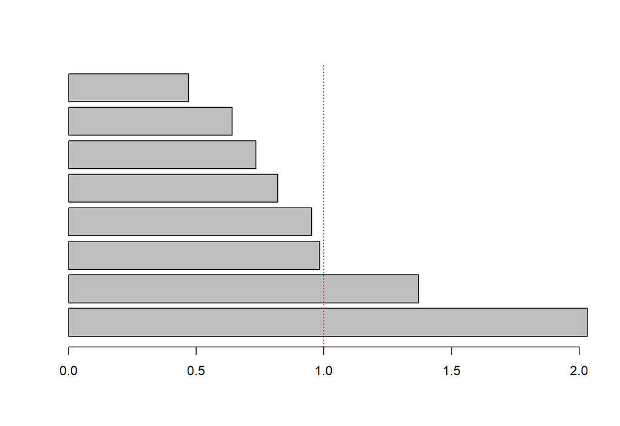

```r
barplot(acp$eig, horiz = TRUE) # histograma de valores propios
abline(v = 1, lty = 3, col = "red")
```

### **CIRCULO DE CORRELACION**

El circulo de corrrelación es una herramienta que permite visualizar la relación entre las variables originales y los componentes principales. Las variables que están más cerca de los ejes del ACP tienen una mayor correlación con ellos, lo que indica su contribución a la varianza explicada por los componentes.

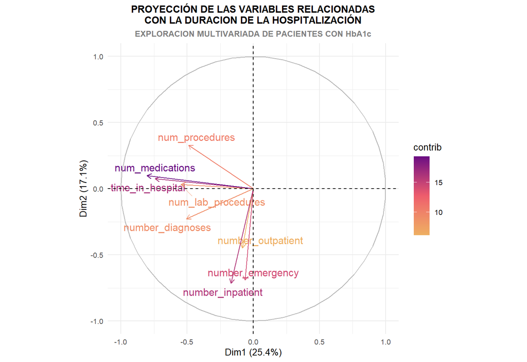

```r
fviz_pca_var(acp, col.var = "contrib", axes = c(1, 2),
             gradient.cols = c("#eeaf61", "#ee5d6c", "#6a0d83"),
             repel = TRUE, geom = c("arrow", "text")) +
  labs(title = "PROYECCIÓN DE LAS VARIABLES RELACIONADAS\nCON LA DURACION DE LA HOSPITALIZACIÓN",
       subtitle = "EXPLORACION MULTIVARIADA DE PACIENTES CON HbA1c") +
  theme_minimal() +
  theme(plot.title = element_text(size = 11, face = "bold", hjust = 0.5),
        plot.subtitle = element_text(size = 9, face = "bold", hjust = 0.5, color = "grey50"),
        text = element_text(size = 10),
        legend.position = "right")
```

### **PROYECCIÓN DE LOS PACIENTES EN EL PLANO**

En nuestro caso la proyección en el plano de los dos primeros componentes principales nos permitirá visualizar la distribución de los pacientes en función de las variables originales. Esta representación gráfica nos ayudará a identificar patrones y posibles agrupamientos en los datos.

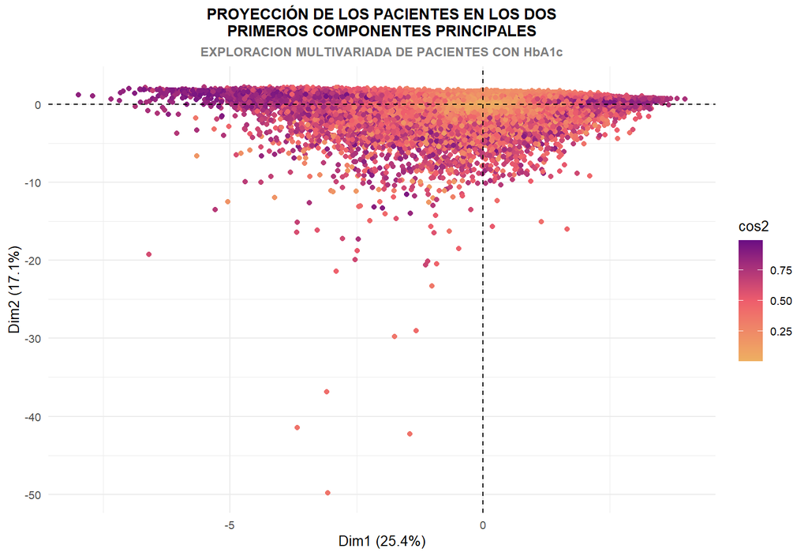

```r
# Proyeccion de los primero 10mil datos en el plano de los dos primeros componentes principales con % de inercia en los ejes

fviz_pca_ind(acp, col.ind = "cos2", axes = c(1, 2),
             gradient.cols = c("#eeaf61", "#ee5d6c", "#6a0d83"),
             repel = TRUE,geom = "point") +
  labs(title = "PROYECCIÓN DE LOS PACIENTES EN LOS DOS\nPRIMEROS COMPONENTES PRINCIPALES",
       subtitle = "EXPLORACION MULTIVARIADA DE PACIENTES CON HbA1c") +
  theme_minimal() +
  theme(plot.title = element_text(size = 11, face = "bold", hjust = 0.5),
        plot.subtitle = element_text(size = 9, face = "bold", hjust = 0.5, color = "grey50"),
        text = element_text(size = 10),
        legend.position = "right")
```

Como podemos obsevar en la representacion del plano, los pacientes se encuentran distribuidos de manera homogenea en el plano, lo que indica que no se pueden identificar grupos claros de pacientes basados en estas variables.

Dado estos resultados, se propone realizar un ACP por grupos de variables, utilizando los grupos anteriormente identificados utilizando el circulo de correlación, con el objetivo de identificar patrones más claros y simplificar la interpretación de los resultados.

## **ACP PARA GRUPO 1 DE VARIABLES**

Este primer grupo de varibales se relacionan directamente a la duración de la hospitalización y el tratamiento médico, por lo que se espera que las variables estén altamente correlacionadas y se puedan identificar patrones claros en los datos. Por otro lado, tambien se espera que la proyección de los pacientes en el plano de los dos primeros componentes principales muestre una mejor distribucion de los pacientes en el plano con el fin de poder identificar grupos.

```r
# Grupo 1: Variables relacionadas con la duración de la hospitalización y el tratamiento médico

dat2 <- data[, c("time_in_hospital", "num_lab_procedures", "num_medications", "number_diagnoses", "Edad", "Genero", "readmitted", "A1Cresult")]

acp1 <- dudi.pca(dat2[,1:4], scannf = FALSE, nf = 3)
summary(acp1)
```

```
## Class: pca dudi
## Call: dudi.pca(df = dat2[, 1:4], scannf = FALSE, nf = 3)
##
## Total inertia: 4
##
## Eigenvalues:
##     Ax1     Ax2     Ax3     Ax4
##  1.8678  0.8608  0.7444  0.5270
##
## Projected inertia (%):
##     Ax1     Ax2     Ax3     Ax4
##   46.70   21.52   18.61   13.18
##
## Cumulative projected inertia (%):
##     Ax1   Ax1:2   Ax1:3   Ax1:4
##   46.70   68.22   86.82  100.00
```

El análisis de componentes principales para el grupo 1 de variables muestra que los dos primeros componentes explican el 68.22% de la variabilidad total de los datos (46.70% y 21.52% respectivamente). Para capturar más del 75% de la información, se requieren al menos 3 componentes, con lo cual se completaría un 86.82% al estar aplicando la tecnica con 4 variables y tener que tomar las primeras 3, nos indica que, aunque la estructura de los datos es más simple y se puede reducir a una menor dimension sin una pérdida significativa de información aun no es posible reducirlo a dos dimensiones.

```r
inertia(acp1)      # valores propios y porcentajes
```

```
## Inertia information:
## Call: inertia.dudi(x = acp1)
##
## Decomposition of total inertia:
##     inertia     cum  cum(%)
## Ax1  1.8678   1.868   46.70
## Ax2  0.8608   2.729   68.22
## Ax3  0.7444   3.473   86.82
## Ax4  0.5270   4.000  100.00
```

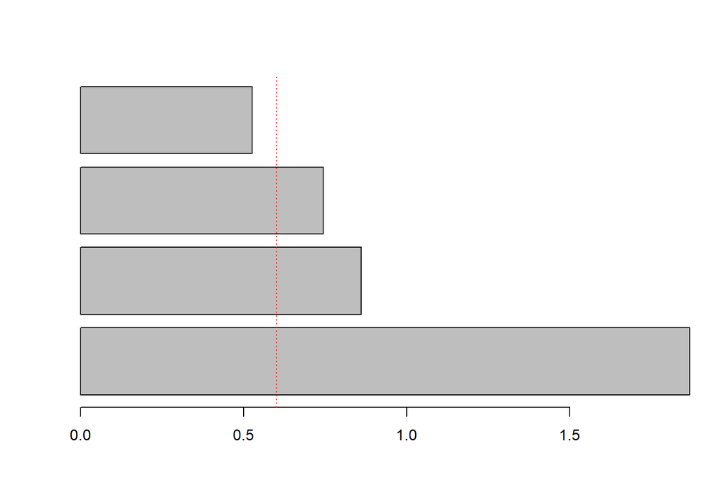

```r
barplot(acp1$eig, horiz = TRUE) # histograma de valores propios
abline(v = 0.6, lwd = 1, lty = 3, col = "red")
```

Viendo el histograma de valores propios,que aunque el primer eje es el más importante y el segundo eje es significativo, el tercer eje también tiene un valor propio importante, por lo que se propone tomar los tres ejes.

### **CIRCULO DE CORRELACION**

En este caso el circulo de correlaciones sera mostrado en las combinaciones posibles de los ejes para poder observar la relación de las variables con los componentes principales.

#### **EJES (1, 2)**

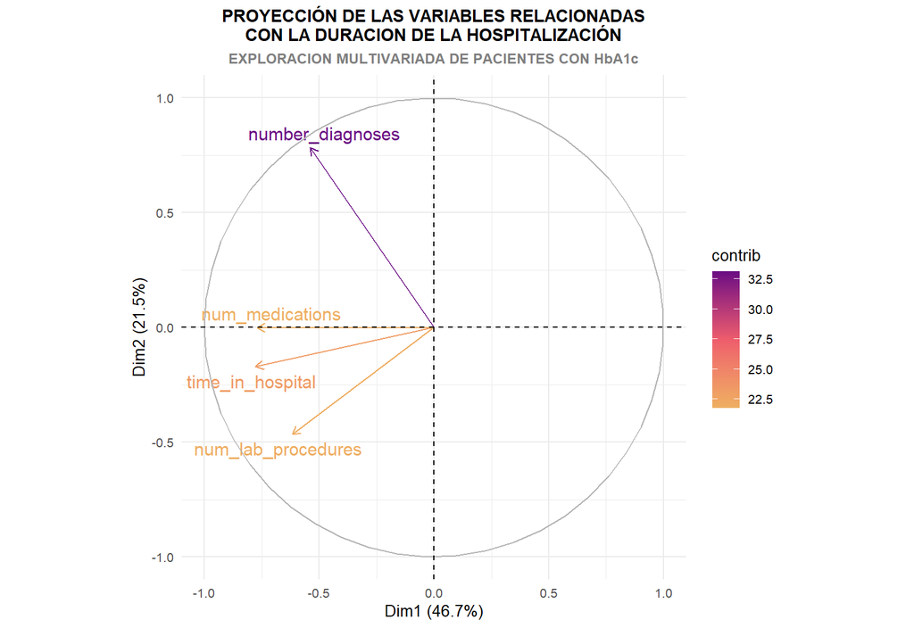

```r
fviz_pca_var(acp1, col.var = "contrib", axes = c(1, 2),
             gradient.cols = c("#eeaf61", "#ee5d6c", "#6a0d83"),
             repel = TRUE, geom = c("arrow", "text")) +
  labs(title = "PROYECCIÓN DE LAS VARIABLES RELACIONADAS\nCON LA DURACION DE LA HOSPITALIZACIÓN",
       subtitle = "EXPLORACION MULTIVARIADA DE PACIENTES CON HbA1c") +
  theme_minimal() +
  theme(plot.title = element_text(size = 11, face = "bold", hjust = 0.5),
        plot.subtitle = element_text(size = 9, face = "bold", hjust = 0.5, color = "grey50"),
        text = element_text(size = 10),
        legend.position = "right")
```

#### **EJES (1, 3)**

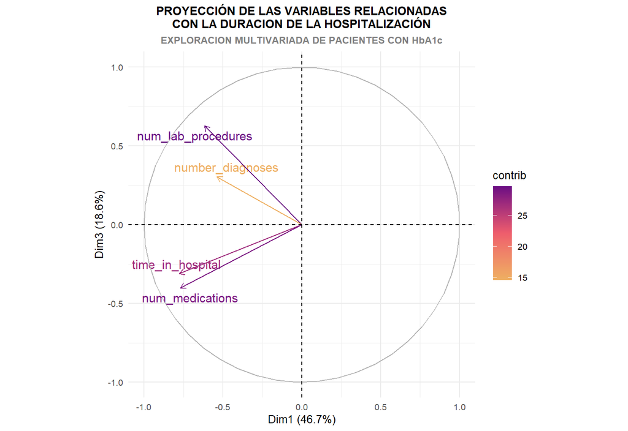

```r
fviz_pca_var(acp1, col.var = "contrib", axes = c(1, 3),
             gradient.cols = c("#eeaf61", "#ee5d6c", "#6a0d83"),
             repel = TRUE, geom = c("arrow", "text")) +
  labs(title = "PROYECCIÓN DE LAS VARIABLES RELACIONADAS\nCON LA DURACION DE LA HOSPITALIZACIÓN",
       subtitle = "EXPLORACION MULTIVARIADA DE PACIENTES CON HbA1c") +
  theme_minimal() +
  theme(plot.title = element_text(size = 11, face = "bold", hjust = 0.5),
        plot.subtitle = element_text(size = 9, face = "bold", hjust = 0.5, color = "grey50"),
        text = element_text(size = 10),
        legend.position = "right")
```

#### **EJES (2, 3)**

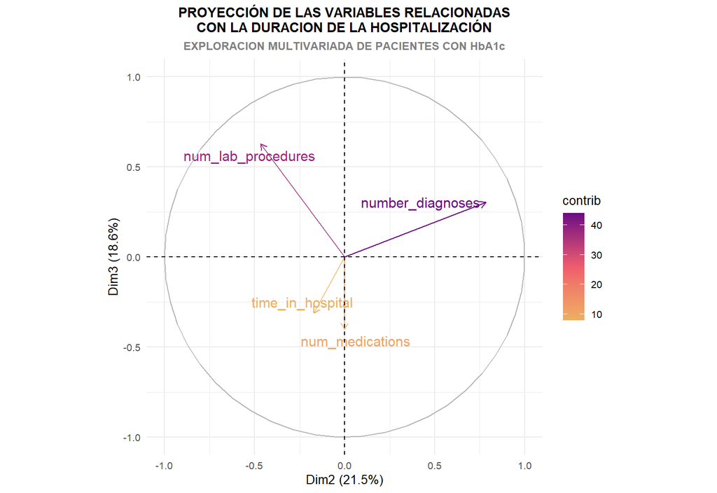

```r
fviz_pca_var(acp1, col.var = "contrib", axes = c(2, 3),
             gradient.cols = c("#eeaf61", "#ee5d6c", "#6a0d83"),
             repel = TRUE, geom = c("arrow", "text")) +
  labs(title = "PROYECCIÓN DE LAS VARIABLES RELACIONADAS\nCON LA DURACION DE LA HOSPITALIZACIÓN",
       subtitle = "EXPLORACION MULTIVARIADA DE PACIENTES CON HbA1c") +
  theme_minimal() +
  theme(plot.title = element_text(size = 11, face = "bold", hjust = 0.5),
        plot.subtitle = element_text(size = 9, face = "bold", hjust = 0.5, color = "grey50"),
        text = element_text(size = 10),
        legend.position = "right")
```

### **PROYECCIÓN DE LOS PACIENTES EN EL PLANO**

Para el caso de la proyeccion en el plano tambien lo haremos considerando los 3 ejes principales, con el objetivo de poder observar la distribución de los pacientes en el plano y poder identificar grupos de pacientes.

#### EJE (1, 2)

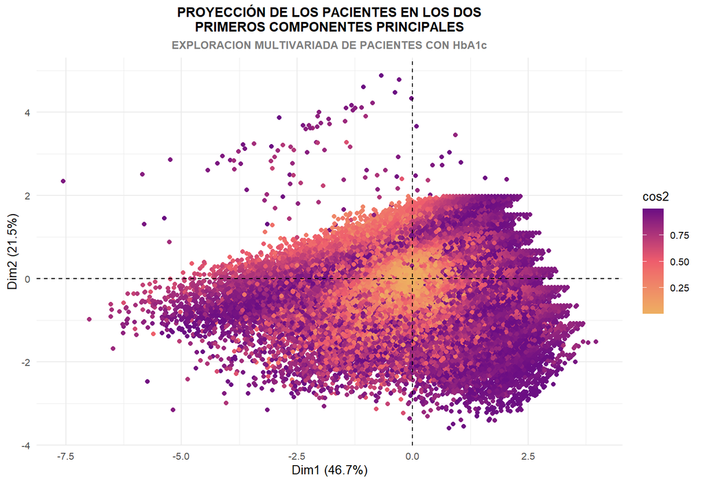

```r
fviz_pca_ind(acp1, col.ind = "cos2", axes = c(1, 2),
             gradient.cols = c("#eeaf61", "#ee5d6c", "#6a0d83"),
             repel = TRUE,geom = "point") +
  labs(title = "PROYECCIÓN DE LOS PACIENTES EN LOS DOS\nPRIMEROS COMPONENTES PRINCIPALES",
       subtitle = "EXPLORACION MULTIVARIADA DE PACIENTES CON HbA1c") +
  theme_minimal() +
  theme(plot.title = element_text(size = 11, face = "bold", hjust = 0.5),
        plot.subtitle = element_text(size = 9, face = "bold", hjust = 0.5, color = "grey50"),
        text = element_text(size = 10),
        legend.position = "right")
```

#### EJE (1, 3)

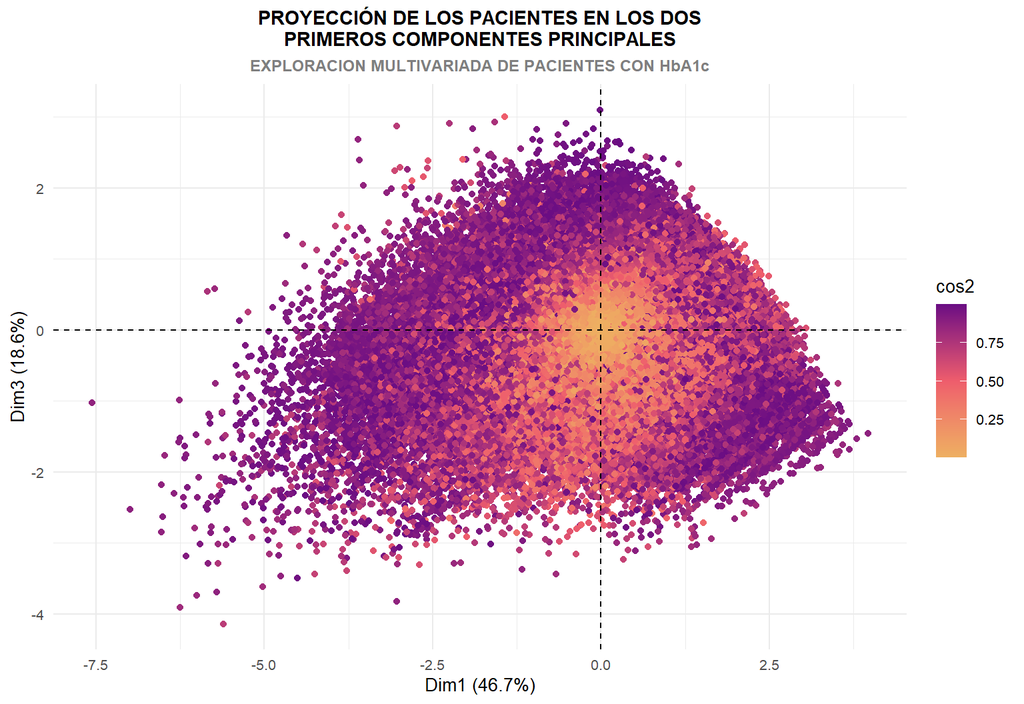

```r
fviz_pca_ind(acp1, col.ind = "cos2", axes = c(1, 3),
             gradient.cols = c("#eeaf61", "#ee5d6c", "#6a0d83"),
             repel = TRUE,geom = "point") +
  labs(title = "PROYECCIÓN DE LOS PACIENTES EN LOS DOS\nPRIMEROS COMPONENTES PRINCIPALES",
       subtitle = "EXPLORACION MULTIVARIADA DE PACIENTES CON HbA1c") +
  theme_minimal() +
  theme(plot.title = element_text(size = 11, face = "bold", hjust = 0.5),
        plot.subtitle = element_text(size = 9, face = "bold", hjust = 0.5, color = "grey50"),
        text = element_text(size = 10),
        legend.position = "right")
```

#### EJE (2, 3)

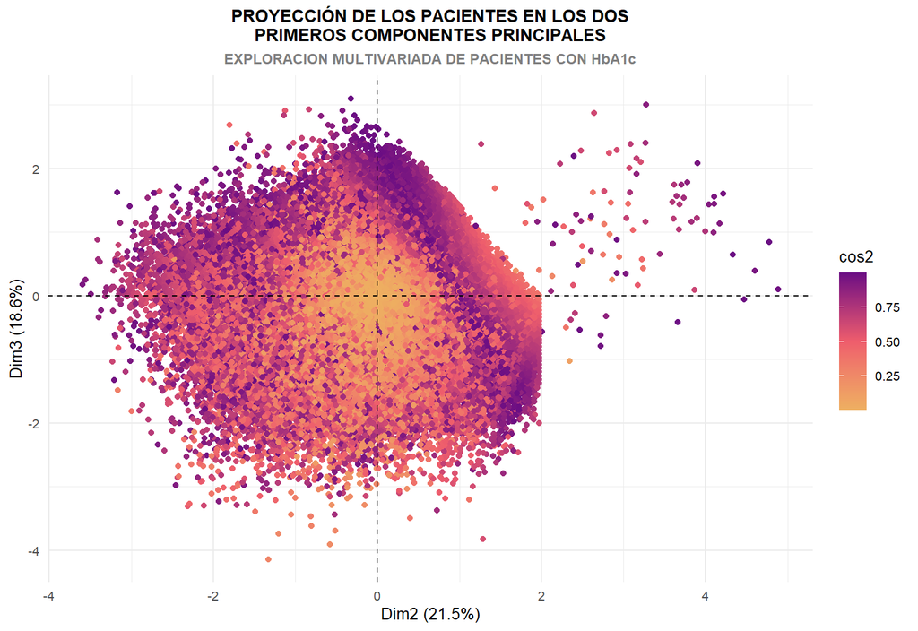

```r
fviz_pca_ind(acp1, col.ind = "cos2", axes = c(2, 3),
             gradient.cols = c("#eeaf61", "#ee5d6c", "#6a0d83"),
             repel = TRUE,geom = "point") +
  labs(title = "PROYECCIÓN DE LOS PACIENTES EN LOS DOS\nPRIMEROS COMPONENTES PRINCIPALES",
       subtitle = "EXPLORACION MULTIVARIADA DE PACIENTES CON HbA1c") +
  theme_minimal() +
  theme(plot.title = element_text(size = 11, face = "bold", hjust = 0.5),
        plot.subtitle = element_text(size = 9, face = "bold", hjust = 0.5, color = "grey50"),
        text = element_text(size = 10),
        legend.position = "right")
```

### PROYECCIÓN CON AGRUPAMIENTO

Esta siguiente proyecion en el plano sera conrepecto a los 2 ejes principales y se hara con agrupamiento por las variables categoricas, con el objetivo de poder identificar grupos de pacientes basados en estas variables.

#### EDAD

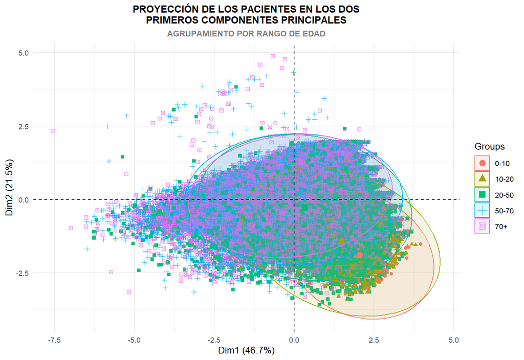

```r
fviz_pca_ind(acp1,
             axes = c(1, 2),
             habillage = dat2[[5]],  # Esto creará grupos por 0 y 1
             addEllipses = TRUE,
             repel = TRUE,
             geom = "point") +
  labs(title = "PROYECCIÓN DE LOS PACIENTES EN LOS DOS\nPRIMEROS COMPONENTES PRINCIPALES",
       subtitle = "AGRUPAMIENTO POR RANGO DE EDAD") +
  theme_minimal() +
  theme(plot.title = element_text(size = 11, face = "bold", hjust = 0.5),
        plot.subtitle = element_text(size = 9, face = "bold", hjust = 0.5, color = "grey50"),
        text = element_text(size = 10),
        legend.position = "right")
```

#### SEXO

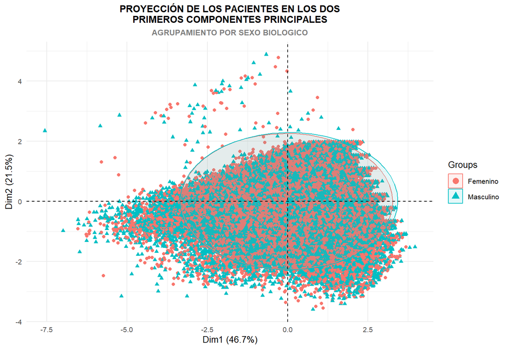

```r
fviz_pca_ind(acp1,
             axes = c(1, 2),
             habillage = dat2[[6]],  # Esto creará grupos por 0 y 1
             addEllipses = TRUE,
             repel = TRUE,
             geom = "point") +
  labs(title = "PROYECCIÓN DE LOS PACIENTES EN LOS DOS\nPRIMEROS COMPONENTES PRINCIPALES",
       subtitle = "AGRUPAMIENTO POR SEXO BIOLOGICO") +
  theme_minimal() +
  theme(plot.title = element_text(size = 11, face = "bold", hjust = 0.5),
        plot.subtitle = element_text(size = 9, face = "bold", hjust = 0.5, color = "grey50"),
        text = element_text(size = 10),
        legend.position = "right")
```

#### REINGRESO

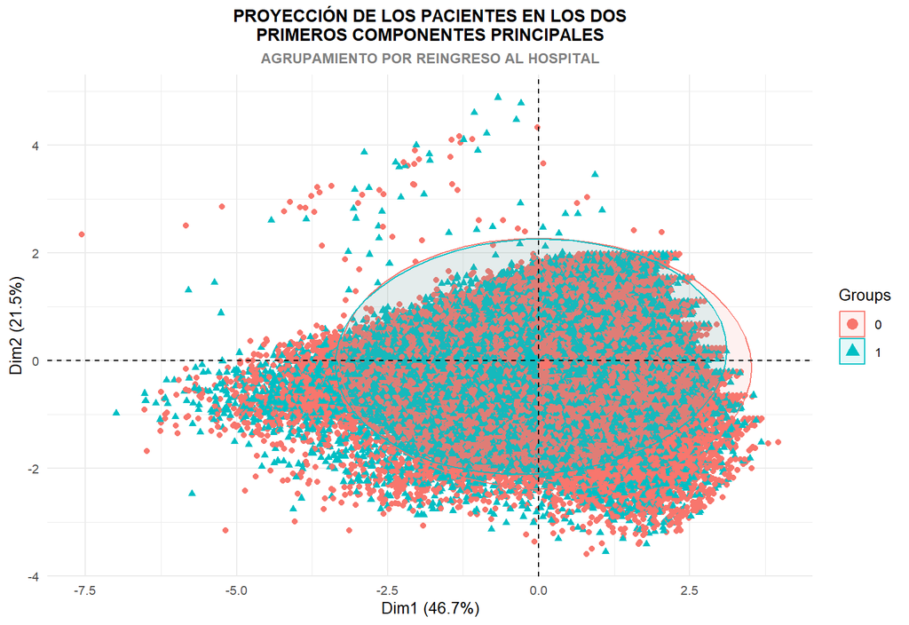

```r
fviz_pca_ind(acp1,
             axes = c(1, 2),
             habillage = dat2[[7]],  # Esto creará grupos por 0 y 1
             addEllipses = TRUE,
             repel = TRUE,
             geom = "point") +
  labs(title = "PROYECCIÓN DE LOS PACIENTES EN LOS DOS\nPRIMEROS COMPONENTES PRINCIPALES",
       subtitle = "AGRUPAMIENTO POR REINGRESO AL HOSPITAL") +
  theme_minimal() +
  theme(plot.title = element_text(size = 11, face = "bold", hjust = 0.5),
        plot.subtitle = element_text(size = 9, face = "bold", hjust = 0.5, color = "grey50"),
        text = element_text(size = 10),
        legend.position = "right")
```

#### PRUEBA A1

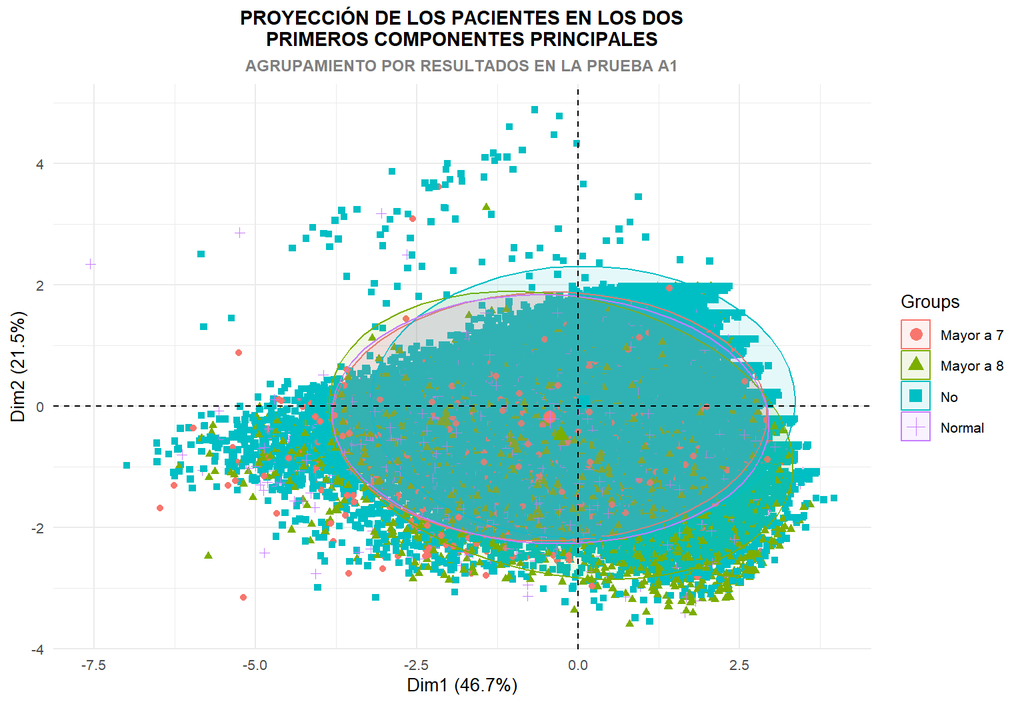

```r
fviz_pca_ind(acp1,
             axes = c(1, 2),
             habillage = dat2[[8]],  # Esto creará grupos por 0 y 1
             addEllipses = TRUE,
             repel = TRUE,
             geom = "point") +
  labs(title = "PROYECCIÓN DE LOS PACIENTES EN LOS DOS\nPRIMEROS COMPONENTES PRINCIPALES",
       subtitle = "AGRUPAMIENTO POR RESULTADOS EN LA PRUEBA A1") +
  theme_minimal() +
  theme(plot.title = element_text(size = 11, face = "bold", hjust = 0.5),
        plot.subtitle = element_text(size = 9, face = "bold", hjust = 0.5, color = "grey50"),
        text = element_text(size = 10),
        legend.position = "right")
```

## **ACP PARA GRUPO 2 DE VARIABLES**

Este grupo de variables se relaciona con las visitas ambulatorias, las emergencias hospitalarias y los procedimientos médicos, por lo que se espera que las variables estén altamente correlacionadas y se puedan identificar patrones claros en los datos. Por otro lado, tambien se espera que la proyección de los pacientes en el plano de los dos primeros componentes principales muestre una mejor distribucion de los pacientes en el plano con el fin de poder identificar grupos.

```r
# Grupo 2: Variables relacionadas con las visitas ambulatorias, las emergencias hospitalarias y los procedimientos médicos

dat3 <- data[, c("number_outpatient", "number_emergency", "number_inpatient", "num_procedures", "number_diagnoses", "Edad", "Genero", "readmitted", "A1Cresult")]

acp2 <- dudi.pca(dat3[,1:5], scannf = FALSE, nf = 3)
summary(acp2)
```

```
## Class: pca dudi
## Call: dudi.pca(df = dat3[, 1:5], scannf = FALSE, nf = 3)
##
## Total inertia: 5
##
## Eigenvalues:
##     Ax1     Ax2     Ax3     Ax4     Ax5
##  1.3865  1.0763  0.9436  0.8694  0.7242
##
## Projected inertia (%):
##     Ax1     Ax2     Ax3     Ax4     Ax5
##   27.73   21.53   18.87   17.39   14.48
##
## Cumulative projected inertia (%):
##     Ax1   Ax1:2   Ax1:3   Ax1:4   Ax1:5
##   27.73   49.26   68.13   85.52  100.00
```

El análisis de componentes principales para el grupo 2 de variables muestra que los dos primeros componentes explican el 49.26% de la variabilidad total de los datos (27.73% y 21.53% respectivamente). Para capturar más del 75% de la información, se requieren al menos 4 componentes, con lo cual se completaría un 85.52%. Este resultado al igual que el del grupo anterior no es tan bueno, pero, se decidio tomar los 3 ejes principales y continuar con el ejercicio de proyección en el plano.

```r
inertia(acp2)      # valores propios y porcentajes
```

```
## Inertia information:
## Call: inertia.dudi(x = acp2)
##
## Decomposition of total inertia:
##     inertia     cum  cum(%)
## Ax1  1.3865   1.386   27.73
## Ax2  1.0763   2.463   49.26
## Ax3  0.9436   3.406   68.13
## Ax4  0.8694   4.276   85.52
## Ax5  0.7242   5.000  100.00
```

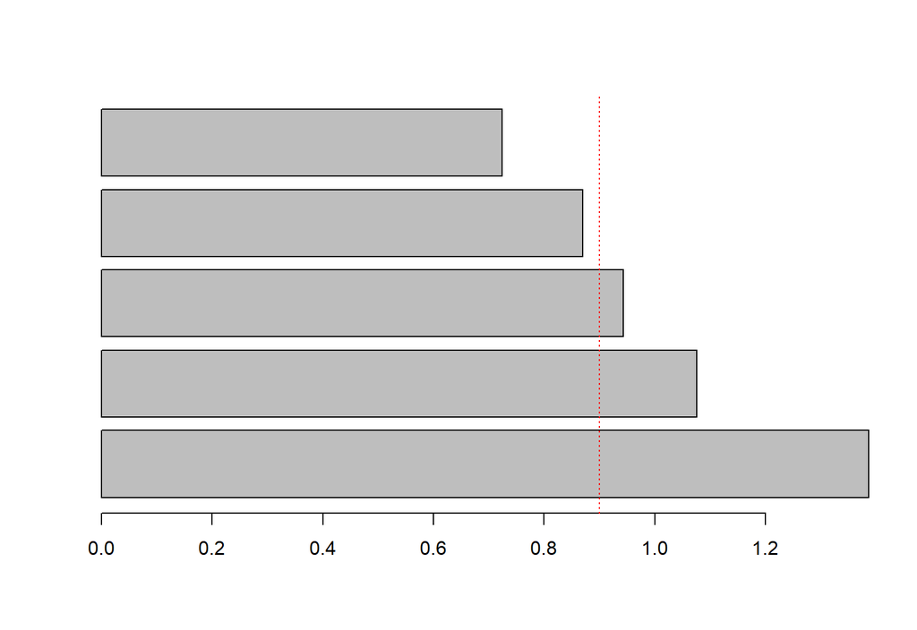

```r
barplot(acp2$eig, horiz = TRUE) # histograma de valores propios
abline(v = 0.9, lwd = 1, lty = 3, col = "red")
```

### **CIRCULO DE CORRELACION**

En este caso el circulo de correlaciones sera mostrado en las combinaciones posibles de los ejes para poder observar la relación de las variables con los componentes principales.

#### **EJES (1, 2)**

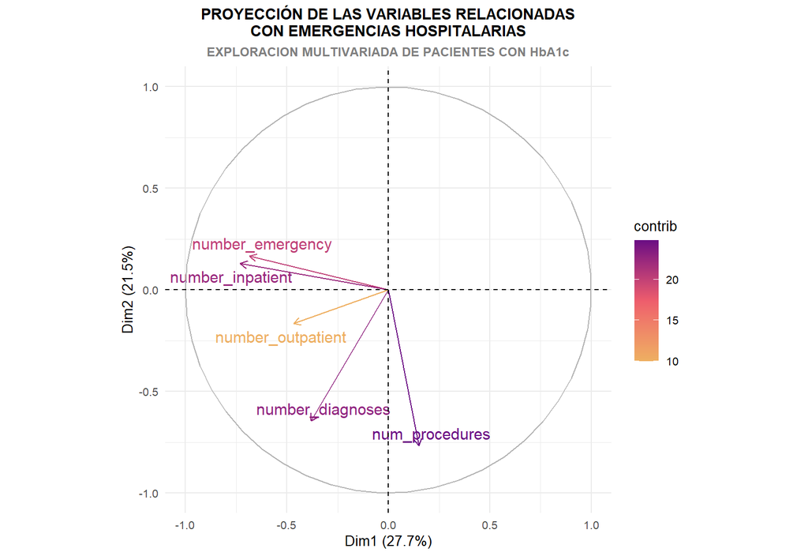

```r
fviz_pca_var(acp2, col.var = "contrib", axes = c(1, 2),
             gradient.cols = c("#eeaf61", "#ee5d6c", "#6a0d83"),
             repel = TRUE, geom = c("arrow", "text")) +
  labs(title = "PROYECCIÓN DE LAS VARIABLES RELACIONADAS\nCON EMERGENCIAS HOSPITALARIAS",
       subtitle = "EXPLORACION MULTIVARIADA DE PACIENTES CON HbA1c") +
  theme_minimal() +
  theme(plot.title = element_text(size = 11, face = "bold", hjust = 0.5),
        plot.subtitle = element_text(size = 9, face = "bold", hjust = 0.5, color = "grey50"),
        text = element_text(size = 10),
        legend.position = "right")
```

#### **EJES (1, 3)**

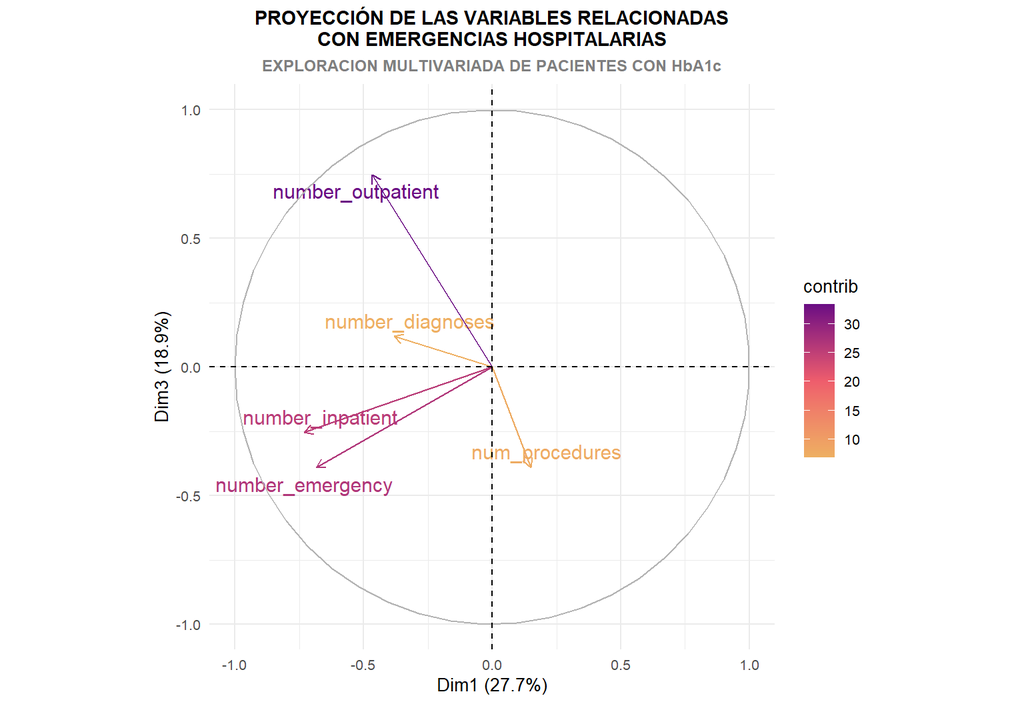

```r
fviz_pca_var(acp2, col.var = "contrib", axes = c(1, 3),
             gradient.cols = c("#eeaf61", "#ee5d6c", "#6a0d83"),
             repel = TRUE, geom = c("arrow", "text")) +
  labs(title = "PROYECCIÓN DE LAS VARIABLES RELACIONADAS\nCON EMERGENCIAS HOSPITALARIAS",
       subtitle = "EXPLORACION MULTIVARIADA DE PACIENTES CON HbA1c") +
  theme_minimal() +
  theme(plot.title = element_text(size = 11, face = "bold", hjust = 0.5),
        plot.subtitle = element_text(size = 9, face = "bold", hjust = 0.5, color = "grey50"),
        text = element_text(size = 10),
        legend.position = "right")
```

#### **EJES (2, 3)**

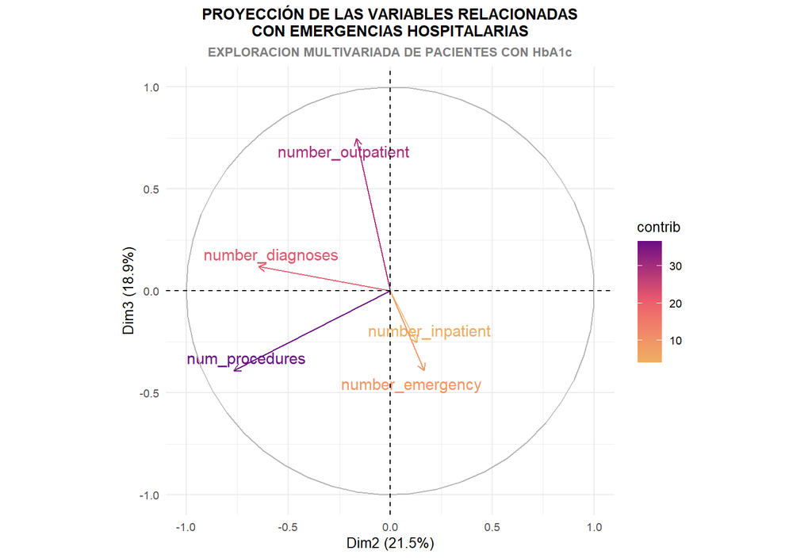

```r
fviz_pca_var(acp2, col.var = "contrib", axes = c(2, 3),
             gradient.cols = c("#eeaf61", "#ee5d6c", "#6a0d83"),
             repel = TRUE, geom = c("arrow", "text")) +
  labs(title = "PROYECCIÓN DE LAS VARIABLES RELACIONADAS\nCON EMERGENCIAS HOSPITALARIAS",
       subtitle = "EXPLORACION MULTIVARIADA DE PACIENTES CON HbA1c") +
  theme_minimal() +
  theme(plot.title = element_text(size = 11, face = "bold", hjust = 0.5),
        plot.subtitle = element_text(size = 9, face = "bold", hjust = 0.5, color = "grey50"),
        text = element_text(size = 10),
        legend.position = "right")
```

### **PROYECCIÓN DE LOS PACIENTES EN EL PLANO**

#### EJE (1, 2)

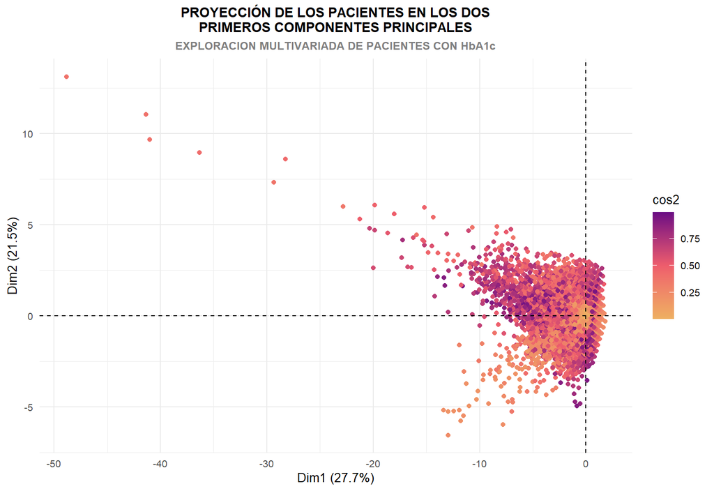

```r
fviz_pca_ind(acp2, col.ind = "cos2", axes = c(1, 2),
             gradient.cols = c("#eeaf61", "#ee5d6c", "#6a0d83"),
             repel = TRUE,geom = "point") +
  labs(title = "PROYECCIÓN DE LOS PACIENTES EN LOS DOS\nPRIMEROS COMPONENTES PRINCIPALES",
       subtitle = "EXPLORACION MULTIVARIADA DE PACIENTES CON HbA1c") +
  theme_minimal() +
  theme(plot.title = element_text(size = 11, face = "bold", hjust = 0.5),
        plot.subtitle = element_text(size = 9, face = "bold", hjust = 0.5, color = "grey50"),
        text = element_text(size = 10),
        legend.position = "right")
```

#### EJE (1, 3)

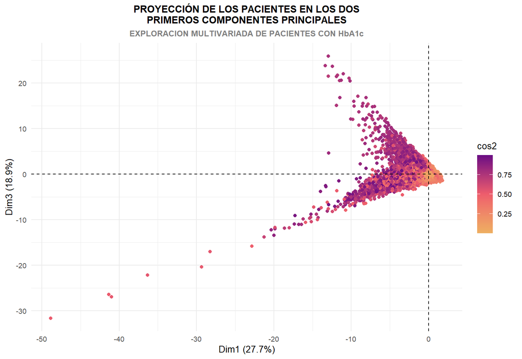

```r
fviz_pca_ind(acp2, col.ind = "cos2", axes = c(1, 3),
             gradient.cols = c("#eeaf61", "#ee5d6c", "#6a0d83"),
             repel = TRUE,geom = "point") +
  labs(title = "PROYECCIÓN DE LOS PACIENTES EN LOS DOS\nPRIMEROS COMPONENTES PRINCIPALES",
       subtitle = "EXPLORACION MULTIVARIADA DE PACIENTES CON HbA1c") +
  theme_minimal() +
  theme(plot.title = element_text(size = 11, face = "bold", hjust = 0.5),
        plot.subtitle = element_text(size = 9, face = "bold", hjust = 0.5, color = "grey50"),
        text = element_text(size = 10),
        legend.position = "right")
```

#### EJE (2, 3)

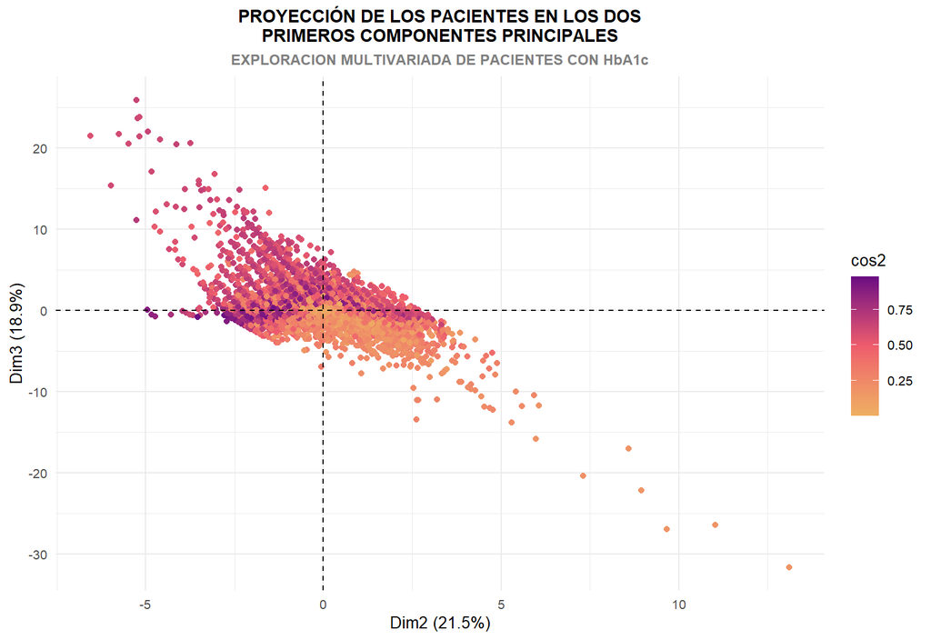

```r
fviz_pca_ind(acp2, col.ind = "cos2", axes = c(2, 3),
             gradient.cols = c("#eeaf61", "#ee5d6c", "#6a0d83"),
             repel = TRUE,geom = "point") +
  labs(title = "PROYECCIÓN DE LOS PACIENTES EN LOS DOS\nPRIMEROS COMPONENTES PRINCIPALES",
       subtitle = "EXPLORACION MULTIVARIADA DE PACIENTES CON HbA1c") +
  theme_minimal() +
  theme(plot.title = element_text(size = 11, face = "bold", hjust = 0.5),
        plot.subtitle = element_text(size = 9, face = "bold", hjust = 0.5, color = "grey50"),
        text = element_text(size = 10),
        legend.position = "right")
```

### PROYECCIÓN CON AGRUPAMIENTO

#### EDAD

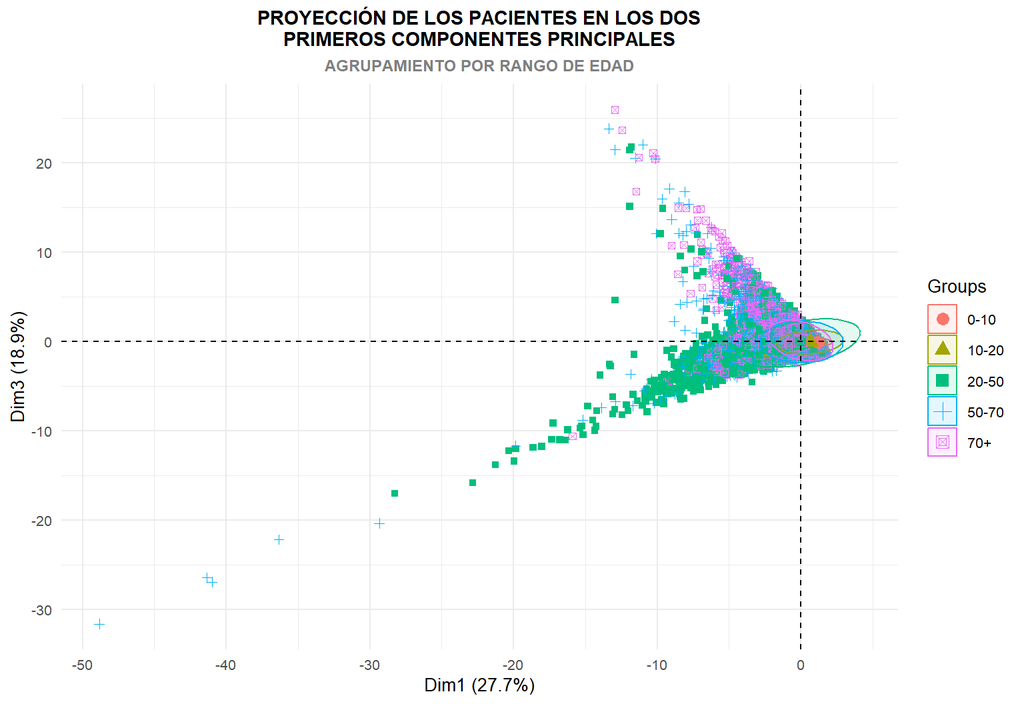

```r
fviz_pca_ind(acp2,
             axes = c(1, 3),
             habillage = dat3[[6]],  # Esto creará grupos por 0 y 1
             addEllipses = TRUE,
             repel = TRUE,
             geom = "point") +
  labs(title = "PROYECCIÓN DE LOS PACIENTES EN LOS DOS\nPRIMEROS COMPONENTES PRINCIPALES",
       subtitle = "AGRUPAMIENTO POR RANGO DE EDAD") +
  theme_minimal() +
  theme(plot.title = element_text(size = 11, face = "bold", hjust = 0.5),
        plot.subtitle = element_text(size = 9, face = "bold", hjust = 0.5, color = "grey50"),
        text = element_text(size = 10),
        legend.position = "right")
```

#### SEXO

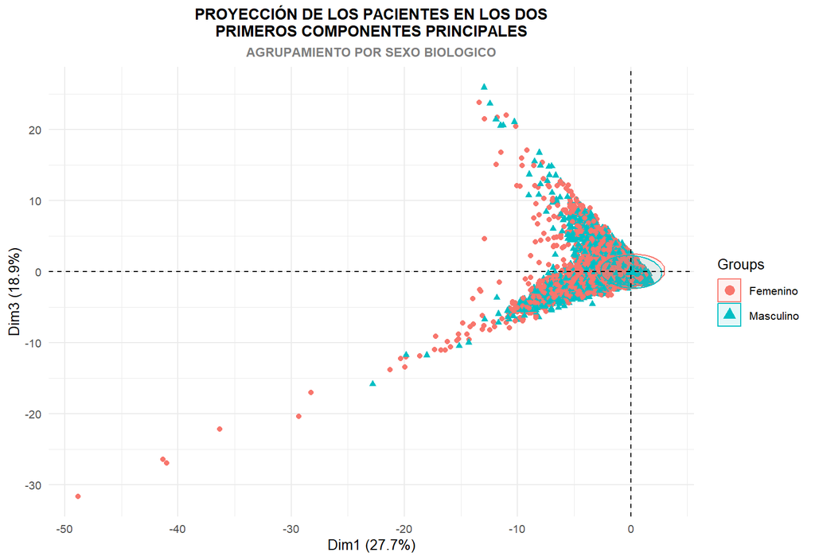

```r
fviz_pca_ind(acp2,
             axes = c(1, 3),
             habillage = dat3[[7]],  # Esto creará grupos por 0 y 1
             addEllipses = TRUE,
             repel = TRUE,
             geom = "point") +
  labs(title = "PROYECCIÓN DE LOS PACIENTES EN LOS DOS\nPRIMEROS COMPONENTES PRINCIPALES",
       subtitle = "AGRUPAMIENTO POR SEXO BIOLOGICO") +
  theme_minimal() +
  theme(plot.title = element_text(size = 11, face = "bold", hjust = 0.5),
        plot.subtitle = element_text(size = 9, face = "bold", hjust = 0.5, color = "grey50"),
        text = element_text(size = 10),
        legend.position = "right")
```